# Mining Impactful Discoveries 2: Analysis

Erwan Moreau

November 2021

# medline-discoveries: analysis

## Overview

- [The main documentation](https://erwanm.github.io/medline-discoveries/1-detecting-surges.html) describes how to generate the output data (i.e. detecting surges) using the provided R implementation.
- This part of the documentation covers additional analysis of the results, including how the graphs and tables presented in the paper are obtained.

### Rmd Options

This document was generated from an [R Markdown](https://rmarkdown.rstudio.com/) source file. The source file is provided in the repository, allowing full reproducibility of the experiments presented in the paper. It can be executed through the RStudio interface (“knit” button) or as follows:

```
rmarkdown::render('2-analysis.Rmd')
```

The `.Rmd` source document can be configured by modifying the following lines:

```r
# directory for the input data (Medline frequency data)
dataPathInput <- 'data/input'
dataPathInputStatic <- paste(dataPathInput,'static',sep='/')
# directory for the output data (extracted surges from the main process in step 1)
dataPathOutput <- 'data/output'

# by default using the Medline ND subset:
# the static suffix is different from the dynamic one for some reason (sorry for that)
data.suffix <- '.min100.ND'
# uncomment the following line in order to use the full Medline data instead (not tested with this Rmd!):
# data.suffix <- '.min100'

# set to TRUE for quick execution with a random subset of the data
shortVersion <- FALSE
# set to TRUE in order to save the graphs used in the paper
savePaperGraphs <- TRUE
```

Notes:

- If the option `shortVersion` is set to `FALSE`, the process requires at least 128GB RAM.
- Note: the option to use the full Medline data (`data.suffix <- '.min100'`) has not been tested with this Rmd document.

```r
source('discoveries.R')
```

## Requirements

The software requirements are the same as for the first part

This part requires the same input data as in the first part, but also the output generated as a result of applying the process. Both datasets can be downloaded from https://zenodo.org/record/5888572.

By default the input data is expected in the subdirectory `data/input` and the output data (unsurprisingly) in `data/output`.

## Loading

```r
dynamic_joint <- loadDynamicData(dataPathInput,suffix=data.suffix, indivOrJoint = 'joint')
dynamic_indiv <- loadDynamicData(dataPathInput,suffix=data.suffix, indivOrJoint = 'indiv')
dynamic_total <- loadDynamicTotalFile(dataPathInput)
static_data <- loadStaticData(dir=dataPathInputStatic,suffix=data.suffix)
```

## Selecting some of the specific concepts presented in the paper

```r
als <- filterConcepts(dynamic_joint, 'D000690')
selectedALS <- filterConcepts(als,c('D051379','D000073885','D000870','D019782','D008875'))
parkinson <- filterConcepts(dynamic_joint, 'D010300')
caseParkinson <- filterConcepts(parkinson, 'D013378')
```

## Selecting a random subset

Note: in some of the graphs (trend distribution), the representation of all the points is very computationally heavy, causing extremely long duration even to just load the pdf file. This is why a random subset of relations is used even in the case where `shortVersion` is set to `FALSE`.

```r
if (shortVersion) {
  dynamic_joint<-pickRandomDynamic(dynamic_joint,n=1000)
  dynamic_joint.rndsubset<-dynamic_joint
} else {
  dynamic_joint.rndsubset<-pickRandomDynamic(dynamic_joint,n=20000)
}
```

```
## [1] "selecting among n pairs =  290797"
```

In order to avoid cases with insufficient data, it is possible to filter out rows with less than some minimum frequency $m$ (the relation must have at least one year with a frequency higher than $m$). It is also possible to specify the number of cases to pick:

```r
three_relations<-pickRandomDynamic(dynamic_joint,n=3, minFreqYear = 200)
```

```
## [1] "selecting among n pairs =  25266"
```

## Displaying relations frequency across time with their concepts names

Using the relations selected randomly above:

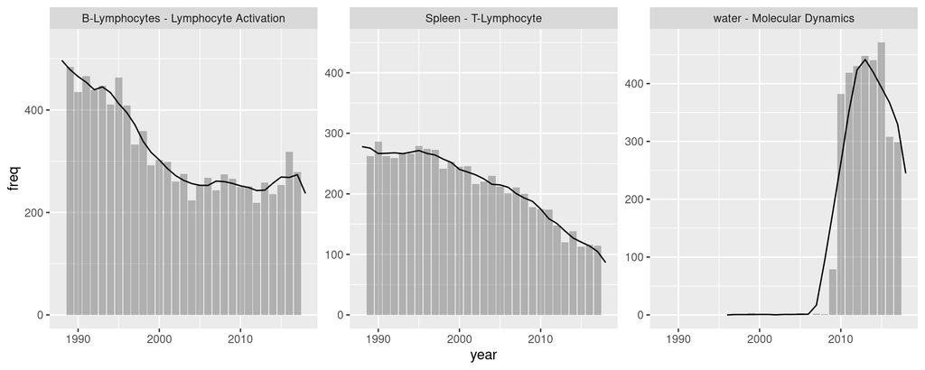

```r
displaySeveralPairsData(three_relations,static_data,dynamic_total)
```

## Displaying the ALS cases

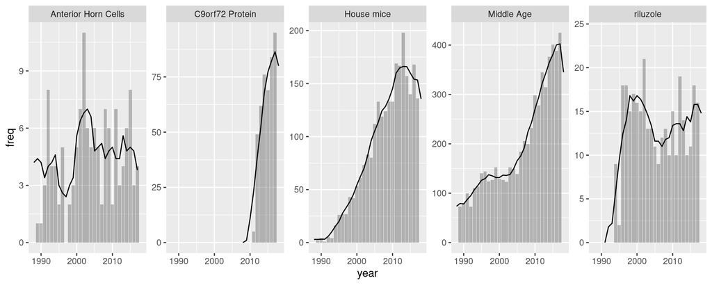

```r
g<-displaySeveralPairsData(selectedALS,static_data,dynamic_total,excludeConceptsFromName = 'D000690',ncol=5)
g
```

```r
ggsave('expl1.pdf',g)
```

## Displaying measures

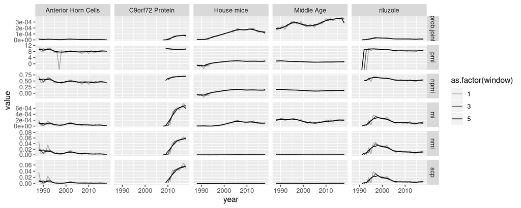

```r
g <- displayMultiMeasure(selectedALS,dynamic_indiv,dynamic_total,static_data,windows=c(1,3,5),measures=c('prob.joint','pmi','npmi','mi','nmi','scp'),excludeConceptsFromName = 'D000690')
g
```

```r
ggsave('expl-measures.pdf',g+ theme(text=element_text(size=14),legend.position="none",axis.title.x=element_blank(),axis.title.y=element_blank()),width=20,height=16,units = "cm")
```

## Study of the trend parameters

### Using simple frequency, indicator ‘rate’

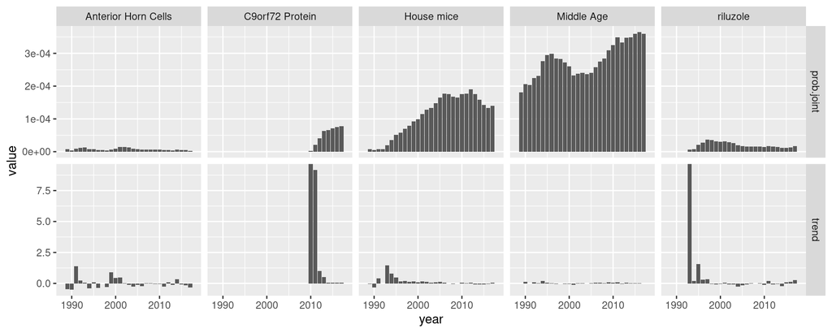

```r
displayMultiTrend(selectedALS,dynamic_indiv,dynamic_total,static_data,indicator='rate',measure = 'prob.joint',excludeConceptsFromName = 'D000690')
```

### Using NMI, indicator ‘rate’

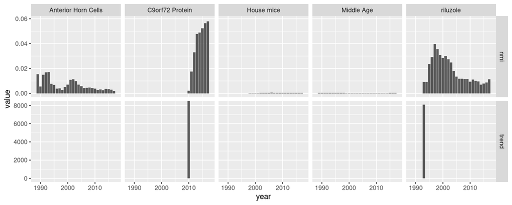

```r
displayMultiTrend(selectedALS,dynamic_indiv,dynamic_total,static_data,indicator='rate',measure = 'nmi',excludeConceptsFromName = 'D000690')
```

### Using NMI, indicator ‘diff’

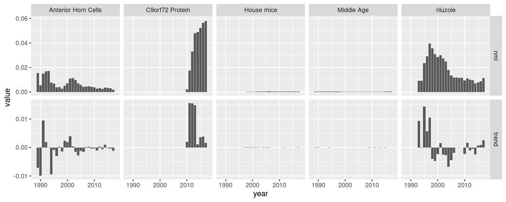

```r
displayMultiTrend(selectedALS,dynamic_indiv,dynamic_total,static_data,indicator='diff',measure = 'nmi',excludeConceptsFromName = 'D000690')
```

## Examples for indicators and surges

This graph shows the surge year(s) in the plot of the probability across years (this is not very useful actually).

### Using simple frequency

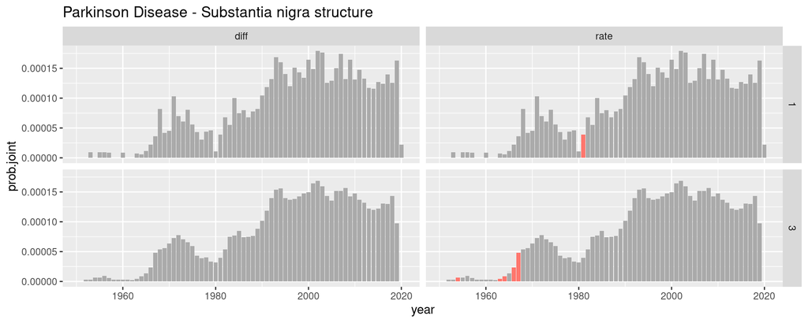

```r
g <- displaySurges(caseParkinson,dynamic_indiv,dynamic_total,static_data,windows=c(1,3), indicators=c('rate','diff'),withTitle = TRUE)
g
```

### Using NMI

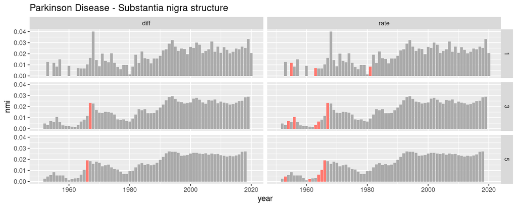

```r
g <- displaySurges(caseParkinson,dynamic_indiv,dynamic_total,static_data,valueCol='nmi',windows=c(1,3,5), indicators=c('rate','diff'),withTitle = TRUE)
g
```

```r
# saving the graph as pdf:
# ggsave('expl1.pdf',g)
```

## Displaying the trend distribution

### ‘Standard’ version

```r
relations.ma <- computeMovingAverage(dynamic_joint.rndsubset,dynamic_total, window=5)
indiv.ma <- computeMovingAverage(dynamic_indiv,dynamic_total, window=5)
```

The following graphs show different versions of the histogram of the `trend` values: with/without logarithmic scale on the X and/or Y axis.

The vertical lines show the outlier threshold calculated as $Q_3+k \times IQR$, where $k$ is either 1.5 or 3 (“far outliers”).

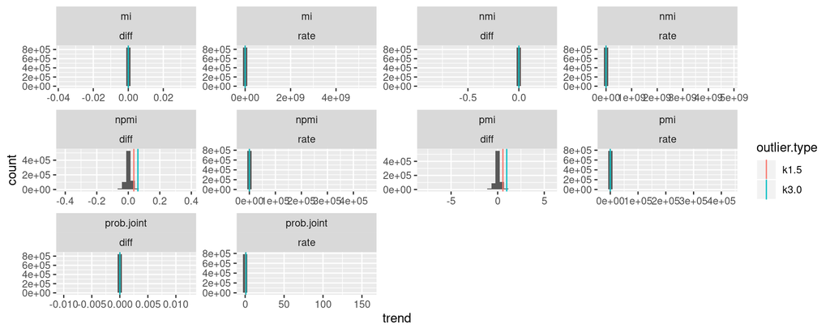

```r
l<-displayTrendDistribution1(relations.ma,indiv.ma)
l$x0.y0
```

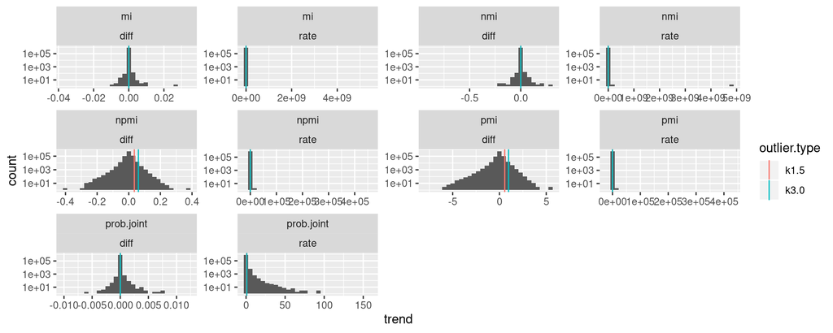

```r
l$x0.y1
```

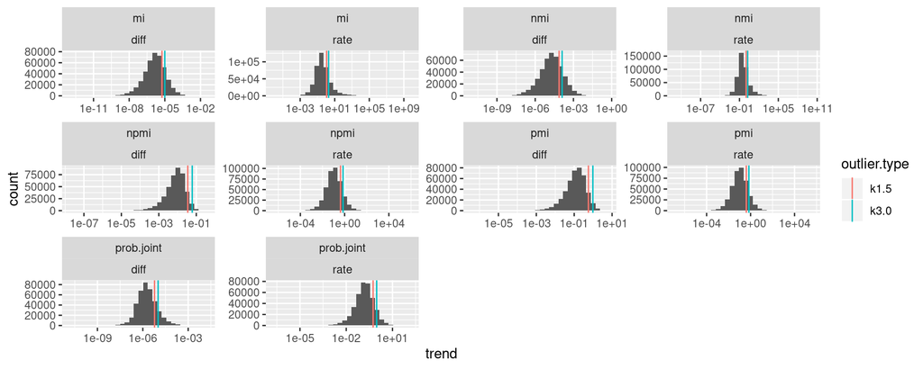

```r
l$x1.y0
```

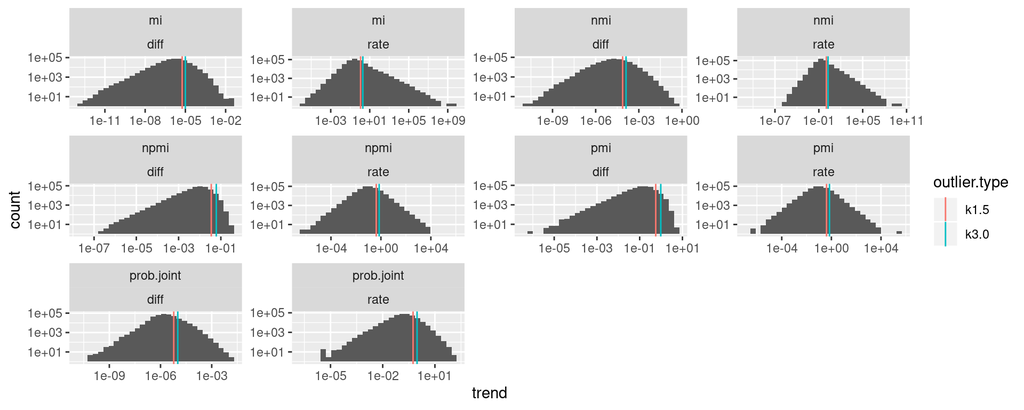

```r
l$x1.y1
```

### Quantile plot (“flat” distribution)

These graphs show the “flat” distribution (probably not a standard name):

Note that the random selection can affect the graph significantly since the extreme points are rare.

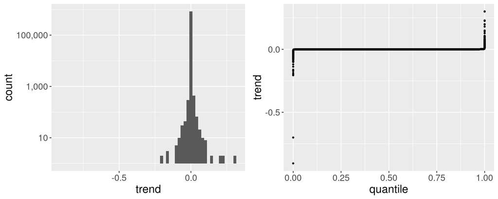

```r
#displayTrendDistribution2(relations.ma,indiv.ma,withRect = FALSE)
g<-displayTwoPlotsDistribTrend(relations.ma,indiv.ma)
g
```

Note: the `pdf` format makes the graph take a very long time to load, this is why `png` is recommended for this graph.

```r
ggsave('expl-trend-distrib.pdf',g,width=20,height=8,units = "cm")
ggsave('expl-trend-distrib.png',g,width=20,height=8,units = "cm")
```

# Evaluation

## Gold standard data

Below the gold-standard dataset presented in the paper is loaded and displayed:

```r
gold <- loadGoldDiscoveries(dir='data',file='ND-discoveries-year.tsv')
kable(gold)
```

| c1 | c2 | term.c1 | group.c1 | term.c2 | group.c2 | year |
| --- | --- | --- | --- | --- | --- | --- |
| D002894 | D006816 | Chromosomes, Human, Pair 4 | NA | Huntington Disease | DISO | 1983 |
| D000071617 | D010300 | Protein Deglycase DJ-1 | CHEM | Parkinson Disease | DISO | 2003 |
| D000690 | D057180 | Amyotrophic Lateral Sclerosis | DISO | Frontotemporal dementia | DISO | 2009 |
| D000073885 | D057180 | C9orf72 Protein | CHEM | Frontotemporal dementia | DISO | 2009 |
| D000073885 | D000690 | C9orf72 Protein | CHEM | Amyotrophic Lateral Sclerosis | DISO | 2009 |
| D000072105 | D000690 | superoxide dismutase 1 | CHEM | Amyotrophic Lateral Sclerosis | DISO | 1993 |
| D000068836 | D000544 | rivastigmine | CHEM | Alzheimer’s Disease | DISO | 1997 |
| D007980 | D010300 | levodopa | CHEM | Parkinson Disease | DISO | 1961 |
| D007980 | D020734 | levodopa | CHEM | Parkinsonian Disorders | DISO | 1961 |
| D000544 | D001714 | Alzheimer’s Disease | DISO | Bipolar Disorder | DISO | 2019 |
| D004298 | D010300 | dopamine | CHEM | Parkinson Disease | DISO | 1971 |
| D004298 | D012559 | dopamine | CHEM | Schizophrenia | DISO | 1977 |

## Parameters

```r
if (shortVersion) {
  my.measures <- c('prob.joint','pmi','nmi','scp')
  my.ma <- c(1,5)
  my.indicators <- 'diff'
} else {
  my.measures <- c('prob.joint','pmi','npmi','mi','nmi','scp')
  my.ma <- c(1,3,5)
  my.indicators <- c('diff',"rate")
}
data.eval <- collectEvalDataSurgesAgainstGold(gold, dir=dataPathOutput,suffix=data.suffix,evalAt=NA,ma_windows=my.ma,measures=my.measures,indicators = my.indicators)
```

```
## [1] "data/output/prob.joint.diff.1.min100.ND.tsv"
## [1] "data/output/prob.joint.rate.1.min100.ND.tsv"
## [1] "data/output/pmi.diff.1.min100.ND.tsv"
## [1] "data/output/pmi.rate.1.min100.ND.tsv"
## [1] "data/output/npmi.diff.1.min100.ND.tsv"
## [1] "data/output/npmi.rate.1.min100.ND.tsv"
## [1] "data/output/mi.diff.1.min100.ND.tsv"
## [1] "data/output/mi.rate.1.min100.ND.tsv"
## [1] "data/output/nmi.diff.1.min100.ND.tsv"
## [1] "data/output/nmi.rate.1.min100.ND.tsv"
## [1] "data/output/scp.diff.1.min100.ND.tsv"
## [1] "data/output/scp.rate.1.min100.ND.tsv"
## [1] "data/output/prob.joint.diff.3.min100.ND.tsv"
## [1] "data/output/prob.joint.rate.3.min100.ND.tsv"
## [1] "data/output/pmi.diff.3.min100.ND.tsv"
```

[output cut: 21 more lines]

```r
res.eval<-evalSurgessAgainstGold(data.eval,eval_windows = c(1,3,5))
```

### Top individual configurations

```r
eval3 <- res.eval[eval.window==3 & mode=='first.year',]
kable(head(eval3[order(-perf),],12))
```

| ma.window | measure | indicator | mode | eval.at | perf | eval.window |
| --- | --- | --- | --- | --- | --- | --- |
| 5 | scp | diff | first.year | NA | 0.6666667 | 3 |
| 1 | nmi | diff | first.year | NA | 0.5833333 | 3 |
| 1 | scp | diff | first.year | NA | 0.5833333 | 3 |
| 3 | nmi | diff | first.year | NA | 0.5833333 | 3 |
| 3 | scp | diff | first.year | NA | 0.5833333 | 3 |
| 5 | nmi | diff | first.year | NA | 0.5833333 | 3 |
| 5 | npmi | diff | first.year | NA | 0.5833333 | 3 |
| 3 | npmi | diff | first.year | NA | 0.5000000 | 3 |
| 5 | prob.joint | rate | first.year | NA | 0.4166667 | 3 |
| 1 | npmi | diff | first.year | NA | 0.2500000 | 3 |
| 3 | prob.joint | rate | first.year | NA | 0.2500000 | 3 |
| 1 | prob.joint | rate | first.year | NA | 0.1666667 | 3 |

### Comparison by parameter

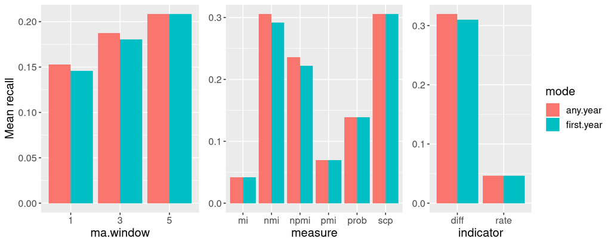

```r
g<-displayAvgPerfByParam(res.eval,evalWindow = 3)
g
```

```r
ggsave('plot-params.pdf',g,width = 20,height=8,unit='cm')
```

### Overlap by pair of configurations

The overlap coefficient is calculated based on the number of relations in common between the two configurations, where “in common” means that the relation appears in both lists with their surge year within 5 years of each other.

- Note: in the code below the window of years (5) can be set to NA. In this case the overlap coefficient is only based on relations in common (no year comparison).

```r
surges<-readMultipleSurgesFiles(measures=my.measures,indicator='diff',ma_windows = my.ma)
```

```
## [1] "data/output/prob.joint.diff.1.min100.ND.tsv"
## [1] "data/output/pmi.diff.1.min100.ND.tsv"
## [1] "data/output/npmi.diff.1.min100.ND.tsv"
## [1] "data/output/mi.diff.1.min100.ND.tsv"
## [1] "data/output/nmi.diff.1.min100.ND.tsv"
## [1] "data/output/scp.diff.1.min100.ND.tsv"
## [1] "data/output/prob.joint.diff.3.min100.ND.tsv"
## [1] "data/output/pmi.diff.3.min100.ND.tsv"
## [1] "data/output/npmi.diff.3.min100.ND.tsv"
## [1] "data/output/mi.diff.3.min100.ND.tsv"
## [1] "data/output/nmi.diff.3.min100.ND.tsv"
## [1] "data/output/scp.diff.3.min100.ND.tsv"
## [1] "data/output/prob.joint.diff.5.min100.ND.tsv"
## [1] "data/output/pmi.diff.5.min100.ND.tsv"
## [1] "data/output/npmi.diff.5.min100.ND.tsv"
## [1] "data/output/mi.diff.5.min100.ND.tsv"
## [1] "data/output/nmi.diff.5.min100.ND.tsv"
## [1] "data/output/scp.diff.5.min100.ND.tsv"
```

```r
mat<-correlationMatrixMultiParam(surges, 5)
```

```
## 1: 2 3 4 5 6 7 8 9 10 11 12 13 14 15 16 17 18
## 2: 3 4 5 6 7 8 9 10 11 12 13 14 15 16 17 18
## 3: 4 5 6 7 8 9 10 11 12 13 14 15 16 17 18
## 4: 5 6 7 8 9 10 11 12 13 14 15 16 17 18
## 5: 6 7 8 9 10 11 12 13 14 15 16 17 18
## 6: 7 8 9 10 11 12 13 14 15 16 17 18
## 7: 8 9 10 11 12 13 14 15 16 17 18
## 8: 9 10 11 12 13 14 15 16 17 18
## 9: 10 11 12 13 14 15 16 17 18
## 10: 11 12 13 14 15 16 17 18
## 11: 12 13 14 15 16 17 18
## 12: 13 14 15 16 17 18
## 13: 14 15 16 17 18
## 14: 15 16 17 18
## 15: 16 17 18
## 16: 17 18
## 17: 18
```

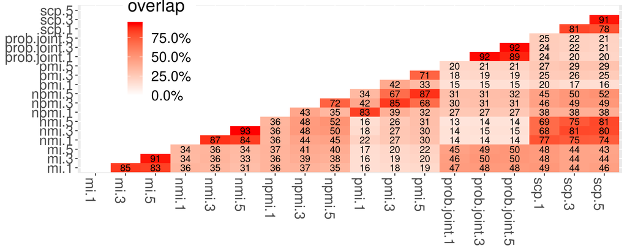

```r
g<-heatMapCommonMatrix(mat)
g
```

```r
ggsave('heatmap-overlap.pdf',g,width=20,height=15,unit='cm')
```

## Distribution of surges across time

### Duration between the year of the first cooccurrence and the surge year

```r
surges.scp <-loadSurgesData(dir=dataPathOutput,suffix = data.suffix,ma_window = 5,measure='scp',indicator = 'diff')
```

```
## [1] "data/output/scp.diff.5.min100.ND.tsv"
```

```r
surges.scp[,first.surge:=(year==min(year)),by=key(surges.scp)]
```

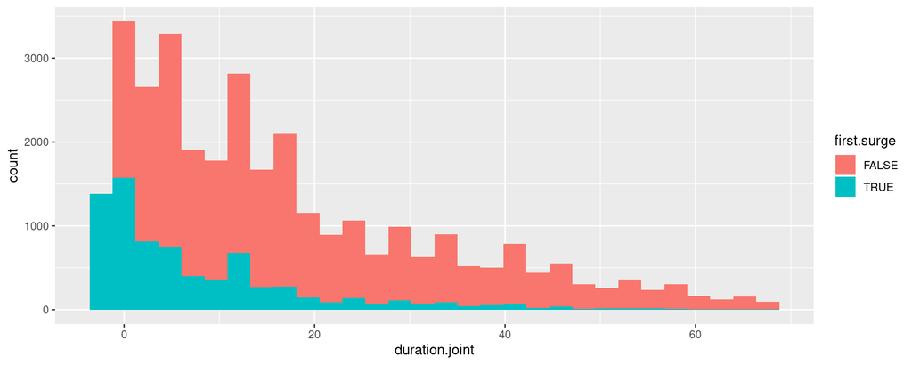

```r
ggplot(surges.scp,aes(duration.joint,fill=first.surge))+geom_histogram()
```

### Trend of surges by year

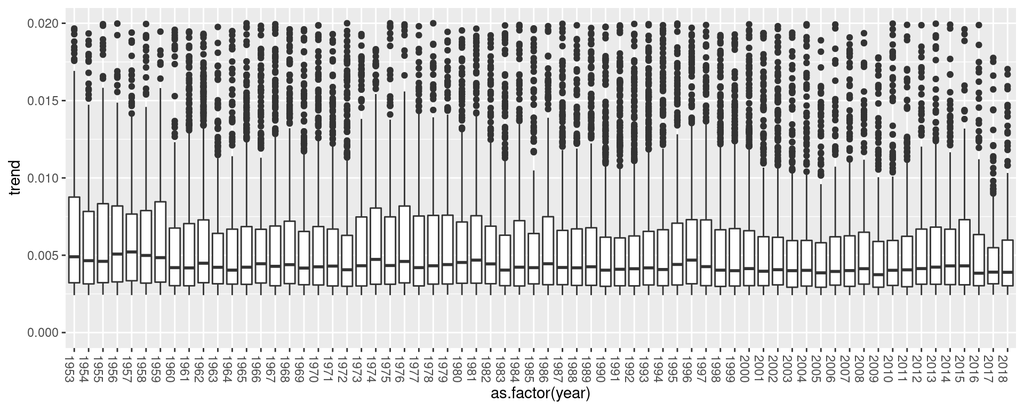

```r
ggplot(surges.scp,aes(as.factor(year),trend))+geom_boxplot()+ylim(c(0,.02))+theme(axis.text.x=element_text(angle = -90, hjust = 0))
```

### First cooccurrences and surges

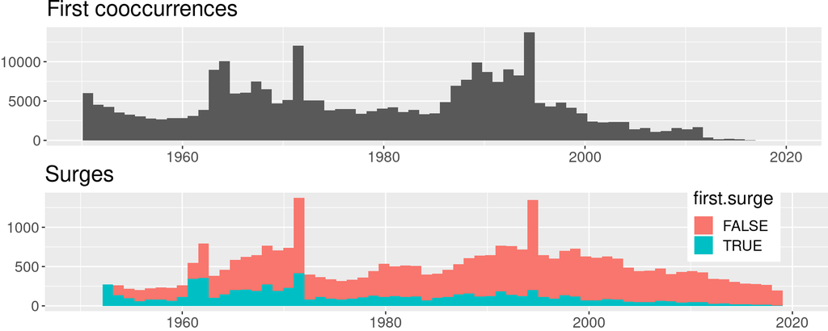

```r
doublePlotAcrossTime(dynamic_joint, surges.scp,bins=68,fontsize=16)
```

### Duration until cooccurrences and until first surge

```r
first.surges.scp <- surges.scp[first.surge==TRUE,]
nrow(first.surges.scp)
```

```
## [1] 7514
```

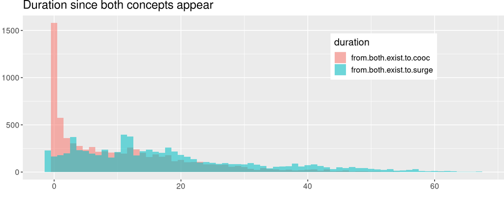

```r
g3 <- plotFirstOccIndivJoint(first.surges.scp)
g3
```

Statistics related to time:

```r
print('average duration between concepts exist and first surge:')
```

```
## [1] "average duration between concepts exist and first surge:"
```

```r
first.surges.scp[,mean(year-year.first.both)]
```

```
## [1] 17.88635
```

```r
print('average duration between concepts exist and first cooccurrence:')
```

```
## [1] "average duration between concepts exist and first cooccurrence:"
```

```r
first.surges.scp[,mean(year.first.joint-year.first.both)]
```

```
## [1] 10.30516
```

```r
print('average duration between first cooccurrence and first surge:')
```

```
## [1] "average duration between first cooccurrence and first surge:"
```

```r
first.surges.scp[,mean(year-year.first.joint)]
```

```
## [1] 7.581182
```

```r
print('distribution (quantiles) for time before cooccurrence:')
```

```
## [1] "distribution (quantiles) for time before cooccurrence:"
```

```r
quantile(first.surges.scp[,year.first.joint-year.first.both],probs=seq(0,1,.1))
```

```
##   0%  10%  20%  30%  40%  50%  60%  70%  80%  90% 100%
##    0    0    0    2    4    7   11   14   18   26   61
```

```r
print('distribution (quantiles) for time before first surge:')
```

```
## [1] "distribution (quantiles) for time before first surge:"
```

```r
quantile(first.surges.scp[,year-year.first.both],probs=seq(0,1,.1))
```

```
##   0%  10%  20%  30%  40%  50%  60%  70%  80%  90% 100%
##   -1    2    5    9   12   15   18   22   29   40   67
```

```r
print('proportion of surges happening the first year the concepts both exist:')
```

```
## [1] "proportion of surges happening the first year the concepts both exist:"
```

```r
nrow(first.surges.scp[year <= year.first.both,])/nrow(first.surges.scp)
```

```
## [1] 0.05270162
```

```r
print('proportion of cooccurrences happening the first year the concepts both exist:')
```

```
## [1] "proportion of cooccurrences happening the first year the concepts both exist:"
```

```r
nrow(first.surges.scp[year.first.joint == year.first.both,])/nrow(first.surges.scp)
```

```
## [1] 0.2102742
```

```r
print('proportion of cooccurrences happening at the same time as first cooccurrence:')
```

```
## [1] "proportion of cooccurrences happening at the same time as first cooccurrence:"
```

```r
nrow(first.surges.scp[year == year.first.joint,])/nrow(first.surges.scp)
```

```
## [1] 0.07040192
```

```r
ggsave('durations.pdf',g3,width=20,height=12,unit='cm')
```

### Combination 2

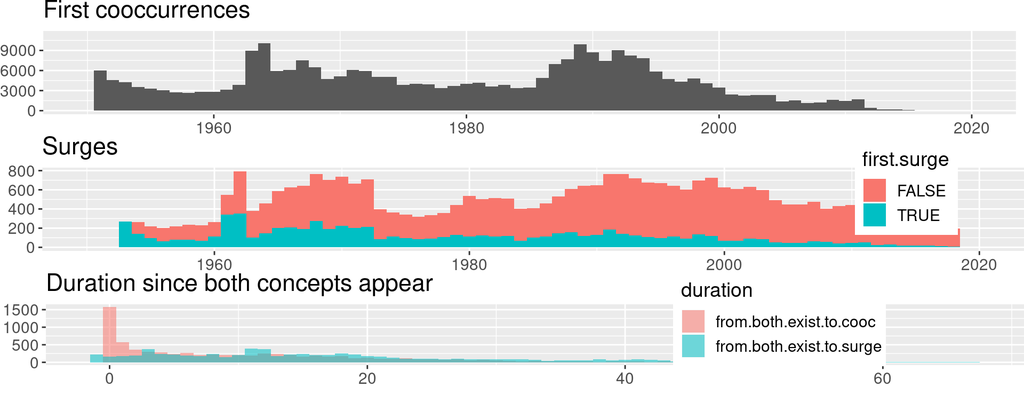

```r
g <- doublePlotAcrossTime(dynamic_joint, surges.scp,addThird = g3)
g
```

```r
ggsave('surges-by-year2.pdf',g,width=20,height=20,unit='cm')
```

## Relation between surges and frequency

Here we observe how the joint frequency of the relation relates to the status as surge or not.

- The joint frequency is taken globally across all years (static data)
- The data is observed by unique relation (pair of concepts), i.e. a relation either has at least one surge or doesn’t (multiple surges not taken into account).

The first graph below shows the distribution of surges by frequency, i.e. how many relations with surge have a particular frequency $x$.

The number of surges decreases when the frequency increases, but we can see below that this an effect of the higher number of relations with low frequency.

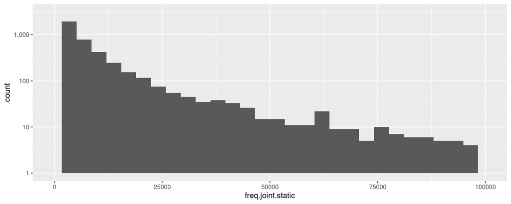

```r
d<-surges.scp
d[,first.surge:=(year==min(year)),by=key(d)]
d<-d[first.surge==TRUE,]
x<-merge(d, static_data,suffixes=c('.dynamic','.static'))
ggplot(x,aes(freq.joint.static))+geom_histogram()+xlim(c(0,100000))+scale_y_log10(labels = scales::comma_format(accuracy=1,big.mark = ",", decimal.mark = "."))
```

The following graph shows the number of relations with a surge among all the relations. Note that the Y axis is logarithmic, this makes the proportion of surges look higher. For instance the first bin contains a few thousands surges among 100 millions relations.

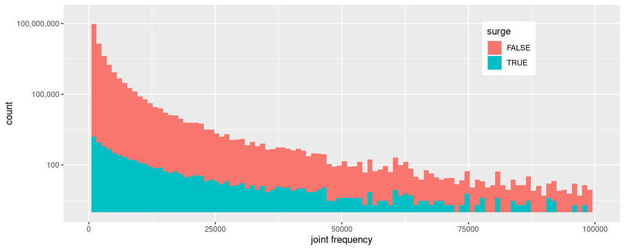

```r
g1 <- surgesAmongRelationsByFreq(surges.scp,static_data)
g1
```

The following graph shows the proportion of relations with surges vs. non surges for every bin. It should be noted that by definition, this graph doesn’t represent the proportion of a bin among the whole data: the first bins (low frequency) contain a lot more relations than the others, as seen above.

The X axis is cut at 10k in order to show the increase of the proportion of surges as frequency increases.

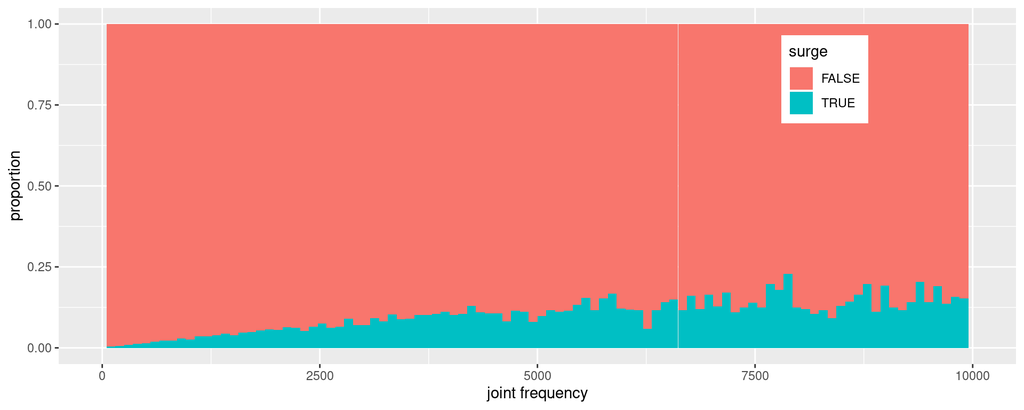

```r
g2 <- surgesAmongRelationsByFreq(surges.scp,static_data,asProportion = TRUE,freqmax = 10000,logY = FALSE)
g2
```

```r
g<-plot_grid(g1,g2,labels=NULL,ncol=2)
ggsave('surges-by-freq.pdf',g,width=20,height=8,unit='cm')
```

## Qualitative results

Here we simply observe the top and bottom surges under various conditions, as described in the paper.

```r
surges.scp[,first.surge:=(year==min(year)),by=key(surges.scp)]
surges.scp.terms <- addRelationName(surges.scp,static_data)
```

These are the top 12 relations by trend without any filtering:

```r
kable(head(surges.scp.terms[order(-trend),.(year,c1,c2,group.c1,group.c2,relation)],12))
```

| year | c1 | c2 | group.c1 | group.c2 | relation |
| --- | --- | --- | --- | --- | --- |
| 1967 | D007980 | D015259 | CHEM | CHEM PHYS | levodopa - Dopaminergic Agents |
| 1968 | D017433 | D017434 | CONC | CONC | Protein Structure, Secondary - Tertiary Protein Structure |
| 1984 | D017510 | D057927 | PHYS | PHEN CONC PHYS | Protein Folding, Globular - Hydrophilicity |
| 1971 | D008279 | D014057 | PROC CONC | PROC | Magnetic Resonance Imaging - Cine-CT |
| 1986 | D020033 | D054875 | CHEM | PHYS | Protein Isoforms - Ubiquitination |
| 1976 | D011994 | D049109 | CHEM | PHYS | Recombinant Proteins - Cell Proliferation |
| 1970 | D015999 | D016000 | CONC | PROC | Multivariate Analysis - statistical cluster |
| 1986 | D017354 | D017931 | DISO | CHEM | Point Mutation - Oligonucleotide Primers |
| 1983 | D017510 | D018360 | PHYS | PROC | Protein Folding, Globular - Crystallography, X-Ray |
| 1981 | D017774 | D056547 | PHYS | ANAT | Long-Term Potentiation - CA1 field |
| 1982 | D017774 | D056547 | PHYS | ANAT | Long-Term Potentiation - CA1 field |
| 1981 | D018836 | D042783 | CHEM | ANAT | Inflammation Mediators - Endothelial Cells |

### Filtering by semantic group

The flitering by semantic group can be done as follows. The [UMLS semantic groups](https://lhncbc.nlm.nih.gov/ii/tools/MetaMap/Docs/SemGroups_2018.txt) are used (the abbreviated name, first column).

```r
filtered <- selectRelationsGroups(surges.scp.terms, groups1=c('CONC'), groups2=c('DISO','LIVB','ANAT'))
```

By default both selected groups are ‘DISO’,‘CHEM’,‘GENE’,‘ANAT’:

```r
filtered <- selectRelationsGroups(surges.scp.terms)
```

Top 12 after filtering:

```r
kable(head(filtered[order(-trend),.(year,c1,c2,group.c1,group.c2,relation)],12))
```

| year | c1 | c2 | group.c1 | group.c2 | relation |
| --- | --- | --- | --- | --- | --- |
| 1986 | D017354 | D017931 | DISO | CHEM | Point Mutation - Oligonucleotide Primers |
| 1981 | D018836 | D042783 | CHEM | ANAT | Inflammation Mediators - Endothelial Cells |
| 1968 | D001402 | D013601 | ANAT | ANAT | B-Lymphocytes - T-Lymphocyte |
| 1962 | D009414 | D020932 | CHEM | CHEM | Nerve Growth Factors - nerve growth factor |
| 1968 | D007155 | D015551 | CHEM | DISO | Biological Response Modifiers - Autoimmune Response |
| 1974 | D012097 | D029721 | CHEM | CHEM | Repressor Proteins - Drosophila Proteins |
| 1959 | D018797 | D048868 | CHEM | CHEM | Cell Cycle Proteins - Adaptor Proteins, Signal Transducing |
| 1996 | D051843 | D051844 | CHEM | CHEM | Synucleins - alpha-Synuclein |
| 1955 | D003342 | D017072 | ANAT | ANAT | Corpus striatum structure - Neostriatum |
| 1976 | D012097 | D014157 | CHEM | CHEM | Repressor Proteins - TRANSCRIPTION FACTOR |
| 1954 | D018797 | D029721 | CHEM | CHEM | Cell Cycle Proteins - Drosophila Proteins |
| 1994 | D020169 | D053148 | CHEM | CHEM | caspase - caspase-3 |

### Filtering by conditional probability

Same relations as above with their conditional probabilities:

```r
kable(head(filtered[order(-trend),.(year,c1,relation,prob.C1GivenC2,prob.C2GivenC1)],12))
```

| year | c1 | relation | prob.C1GivenC2 | prob.C2GivenC1 |
| --- | --- | --- | --- | --- |
| 1986 | D017354 | Point Mutation - Oligonucleotide Primers | 0.5000000 | 1.0000000 |
| 1981 | D018836 | Inflammation Mediators - Endothelial Cells | 1.0000000 | 1.0000000 |
| 1968 | D001402 | B-Lymphocytes - T-Lymphocyte | 0.4000000 | 1.0000000 |
| 1962 | D009414 | Nerve Growth Factors - nerve growth factor | 0.8461538 | 0.5789474 |
| 1968 | D007155 | Biological Response Modifiers - Autoimmune Response | 0.3333333 | 1.0000000 |
| 1974 | D012097 | Repressor Proteins - Drosophila Proteins | 0.5000000 | 1.0000000 |
| 1959 | D018797 | Cell Cycle Proteins - Adaptor Proteins, Signal Transducing | 1.0000000 | 0.3333333 |
| 1996 | D051843 | Synucleins - alpha-Synuclein | 1.0000000 | 0.6666667 |
| 1955 | D003342 | Corpus striatum structure - Neostriatum | 1.0000000 | 0.3684211 |
| 1976 | D012097 | Repressor Proteins - TRANSCRIPTION FACTOR | 0.3611111 | 0.7428571 |
| 1954 | D018797 | Cell Cycle Proteins - Drosophila Proteins | 0.6666667 | 1.0000000 |
| 1994 | D020169 | caspase - caspase-3 | 1.0000000 | 0.6000000 |

Relations with a least one High conditional probability are often trivial, since one of the concepts almost always appears with the other one.

The following function filters out relations which have at least one conditional probability higher than the threshold. It also has an option to keep only the first surge for any relation.

```r
filtered2<-filterCondProb(filtered,conditional.threshold = 0.6,onlyFirstSurge = TRUE)
kable(head(filtered2[order(-trend),.(year,c1,relation,trend)],12))
```

| year | c1 | relation | trend |
| --- | --- | --- | --- |
| 1971 | D016501 | Neurites - nerve growth factor | 0.2500000 |
| 1953 | D000959 | Antihypertensive Agents - reserpine | 0.2051585 |
| 1969 | D002795 | Choline O-Acetyltransferase - Cholinergic Fibers | 0.1666667 |
| 1961 | D008562 | Membrane Glycoproteins - Actin-Binding Protein | 0.1666667 |
| 1978 | D018836 | Inflammation Mediators - Endothelial Cells | 0.1666667 |
| 1981 | D053318 | Apolipoprotein E3 - Apolipoprotein E4 | 0.1666667 |
| 1962 | D001379 | azathioprine - Immunosuppressive Agents | 0.1322751 |
| 1973 | D003924 | Diabetes Mellitus, Non-Insulin-Dependent - treatment failure | 0.1250000 |
| 1972 | D004268 | DNA Helix Destabilizing Proteins - Nuclear Proteins | 0.1111111 |
| 1972 | D004268 | DNA Helix Destabilizing Proteins - Repressor Proteins | 0.1111111 |
| 1972 | D009687 | Nuclear Proteins - Repressor Proteins | 0.1111111 |
| 1954 | D011956 | Receptors, Cell Surface - Drosophila Proteins | 0.1111111 |

```r
kable(head(filtered2[order(-trend),.(year,c1,relation,trend)],12))
```

| year | c1 | relation | trend |
| --- | --- | --- | --- |
| 1971 | D016501 | Neurites - nerve growth factor | 0.2500000 |
| 1953 | D000959 | Antihypertensive Agents - reserpine | 0.2051585 |
| 1969 | D002795 | Choline O-Acetyltransferase - Cholinergic Fibers | 0.1666667 |
| 1961 | D008562 | Membrane Glycoproteins - Actin-Binding Protein | 0.1666667 |
| 1978 | D018836 | Inflammation Mediators - Endothelial Cells | 0.1666667 |
| 1981 | D053318 | Apolipoprotein E3 - Apolipoprotein E4 | 0.1666667 |
| 1962 | D001379 | azathioprine - Immunosuppressive Agents | 0.1322751 |
| 1973 | D003924 | Diabetes Mellitus, Non-Insulin-Dependent - treatment failure | 0.1250000 |
| 1972 | D004268 | DNA Helix Destabilizing Proteins - Nuclear Proteins | 0.1111111 |
| 1972 | D004268 | DNA Helix Destabilizing Proteins - Repressor Proteins | 0.1111111 |
| 1972 | D009687 | Nuclear Proteins - Repressor Proteins | 0.1111111 |
| 1954 | D011956 | Receptors, Cell Surface - Drosophila Proteins | 0.1111111 |

## Comparison against the baseline

This part requires the full Medline data (not only the ND subset):

```r
data.suffix <- '.min100'

surges.scp <- loadSurgesData(dir=dataPathOutput,suffix=data.suffix, measure='scp',indicator='diff',ma_window=5)
```

```
## [1] "data/output/scp.diff.5.min100.tsv"
```

```r
dynamic_joint <- loadDynamicData(dir=dataPathInput,suffix=data.suffix, indivOrJoint = 'joint')
dynamic_indiv <- loadDynamicData(dir=dataPathInput,suffix=data.suffix, indivOrJoint = 'indiv')
dynamic_total <- loadDynamicTotalFile(dir=dataPathInput)
static_data <- loadStaticData(dir=dataPathInputStatic,suffix=data.suffix)
```

### Generating output relations to annotate

*Important:* the data used in the code was generated from the full input set of relations, i.e. with option `data.suffix` set to `'.min100'`.

The following code computes the full list of relations, similarly to the original time sliced evaluation method. This will be used as baseline.

```r
relationsDT <- computeMovingAverage(dynamic_joint,dynamic_total, window=1)
indivDT <- computeMovingAverage(dynamic_indiv,dynamic_total, window=1)
allrels<-addDynamicAssociationToRelations(relationsDT,indivDT,measures = c('prob.joint'))
allrels<-allrels[freq.joint>0,]
```

The code below applies the same preprocessing steps to both the SCP relations and the baseline relations:

```r
set.seed(2022)
scp<-prepareCmpBaseline(surges.scp, static_data)
```

```
## [1] "size relsDT: 315418"
## [1] "size static: 1809993"
## [1] "after filter condi + FIRSTsurge + years:  18343"
## [1] "after filter groups:  9092"
```

```r
scp <- scp[order(-trend),]
baseline<-prepareCmpBaseline(allrels,static_data)
```

```
## [1] "size relsDT: 65370033"
## [1] "size static: 1809993"
## [1] "after filter condi + FIRSTsurge + years:  497070"
## [1] "after filter groups:  108794"
```

We now create the dataset to annotate, containing both some SCP relations and some baseline relations:

- x1/y1 contain a random subset of 100 relations for both methods
- x2/y2 contain the top 100 relations for both methods

The 4 subsets are then concatenated and shuffled.

```r
baseline<-head(baseline[order(-freq.joint),],nrow(scp))
x1<-scp[sample(.N,100),.(c1,c2,term.c1,term.c2,group.c1,group.c2,year)]
y1<-baseline[sample(.N,100), .(c1,c2,term.c1,term.c2,group.c1,group.c2,year)]
x2<-head(scp[,.(c1,c2,term.c1,term.c2,group.c1,group.c2,year)],100)
y2<-head(baseline[, .(c1,c2,term.c1,term.c2,group.c1,group.c2,year)],100)
res <- rbind(x1,y1,x2,y2)
res <- res[sample(.N),]
fwrite(res,'to-annotate.tsv',sep='\t')
```

### Evaluation results

```r
res <- eval.baseline( x1, y1, x2, y2, annotFile='data/annotated-relations.tsv')
```

```
##     method precision
## 1 baseline 0.2985075
## 2      scr 0.4430380
##
##            no yes
##   baseline 47  20
##   scr      44  35
## [1] "chisq.test p-val= 0.104261308387589"
##     method precision
## 1 baseline 0.1785714
## 2      scr 0.3827160
##
##            no yes
##   baseline 69  15
##   scr      50  31
## [1] "chisq.test p-val= 0.00596135278801524"
```

```r
kable(res)
```

| method | subset | answer | number |
| --- | --- | --- | --- |
| scr | rnd | yes | 35 |
| scr | top | yes | 31 |
| baseline | rnd | yes | 20 |
| baseline | top | yes | 15 |
| scr | rnd | no | 44 |
| scr | top | no | 50 |
| baseline | rnd | no | 47 |
| baseline | top | no | 69 |
| scr | rnd | maybe | 21 |
| scr | top | maybe | 19 |
| baseline | rnd | maybe | 33 |
| baseline | top | maybe | 16 |